# Coursework Report

*N* removed NAs: 3

*N* removed <18: 19

*N* total clean: 127

| Group | *N* | *M*<sub>age</sub> | *M*<sub>rating</sub> |
| --- | --- | --- | --- |
| Control | 65 | 20.68 | 6.42 |
| Experim | 62 | 20.79 | 5.42 |

**Main analysis results**

*t*(125) = 9.31, *p* < .001

# Coursework Report

Analysing Data, Spring 2020

# Methods

## Design

The research question being investigated is: Does the colour red influence women’s perception of attractiveness of men? This is an independent measures design study (between groups), therefore each participant only takes part in a singe condition. The independent variable is the colour of the background which has two levels: red (experimental) and white (control). The 3 dependent variables are continuous variables and are measured on rating scales ranging from 1 (not at all) to 9 (extremely attractive). The three rating scales were: “How attractive do you think this person is?”, “How pleasant is this person to look at?”, “If i were to meet this person face to face, I would think he is attractive.” (Elliot, 2010).

The operational hypothesis is those that are in the experimental condition will perceive the man in the photo to be more attractive, demonstrated by higher ratings on the three rating scales, than those who are in the control condition. This will be tested using the statistical analysis t-test.

# Results

The results showed that the ratings on each item scale were relatively similar for both conditions. However, those in the control condition (white background) had a mean rating of 6.42 compared to the mean rating of 5.42 from those in the experimental condition (red background). This shows that on average those in the red background condition found the man in the photo to be less attractive than those in the white background condition.

| Condition | Count | *M*<sub>Question1</sub> | *M*<sub>Question2</sub> | *M*<sub>Question3</sub> | *M*<sub>Attractiveness</sub> |
| --- | --- | --- | --- | --- | --- |
| control | 65 | 6.43 | 6.42 | 6.42 | 6.42 |
| experimental | 62 | 5.44 | 5.48 | 5.34 | 5.42 |

If we look at the composite mean of all three rating scales, we can see that the participants in the experimental condition rated the male in the photo to be less attractive than those who were in the control condition. You can also see that the confidence intervals do not overlap. This means that it is more likely the red effect didn’t occurr.

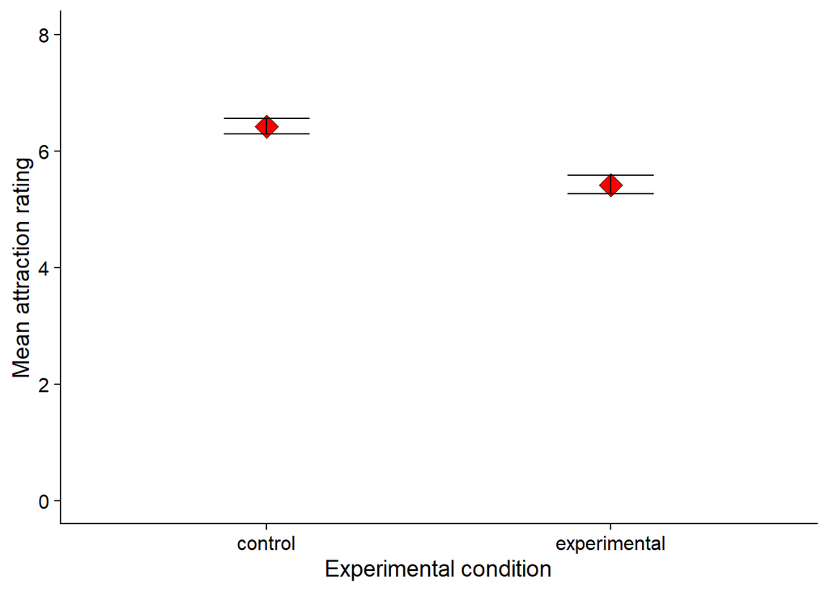

It was investigated whether people who saw a photo of a man on a red background would perceive him to be more attractive than those who saw the identical photo on a white background. This was done by looking at the *t*-test. This showed that the means were not identical and vastly different, (*M*<sub>diff</sub> = 1, 95% CI [0.79, 1.21]) and there was a significant difference between the two groups on ratings of perceived attractiveness (*t* (125) = 9.31, *p* = .0000000).

```
##
##  Two Sample t-test
##
## data:  attract by condition
## t = 9.3144, df = 125, p-value = 0.0000000000000005412
## alternative hypothesis: true difference in means is not equal to 0
## 95 percent confidence interval:
##  0.788433 1.213883
## sample estimates:
##      mean in group control mean in group experimental
##                   6.420513                   5.419355
```

# Discussion

Does the colour red influence women’s perception of attractiveness of men? The statistical test shows that this research question has not been supported as the means of the control and experimental conditions are not identical and the control mean was higher than the experimental mean. The t-test showed that the probability of getting these values or any values more extreme under the null hypothesis to be very unlikely. In other words, the red effect has not occurred. These findings are not the same as what Elliot found, this raises the question of why, and how has the red effect not been replicated. In Elliots study those in the red condition had a mean rating of attractiveness of 6.79 compared to those in the white condition who had a mean rating of attractiveness of 5.67. In the paper it was stated that “red is a novel determinant of desires and preference” (Elliot, 2010). While that may be true, this experiment has not found any evidence that the red effect exists.

Research by Hesslinger and his colleagues found no statistically significant results (Hesslinger, 2015). They completed an exact replication of Elliots experiment 1 using the same image and dimensions except rounded up to 2 significant figures. They also completed a second experiment where they investigated the effects of apparel on attractivess and status. While they found that the men in suits were found to be perceived as more attractive and of a higher status than those in casual clothing, there was **no** significant red effect observed. There was another replication of investigating the red effect done by Peperkoorn, where they investigated the effect of red clothing on attractiveness. They completed three experiments each with different colours and sample of participants and their final experiment was a replication of a study by Elliot but with a larger sample size (Peperkoorn, Roberts, & Pollet, 2016). Over all three experiments no red effect was found. As both these studies found no significant effect red on pereceived attractiveness it could mean that the effect is not consistent across all populations and the reasons for its occurrence are unknown.

A limitation of this experiment is the use of the between groups design. As each participant only partook in one condition we can not see how the other condition would have influenced their perception of attractiveness. This means that the participants in each condition are not matched based on age, gender or any other characteristics, this leads to participant variability. Because of the between groups design the participants only experience one condition, because of this we can not generalise the results to wider populations due to the participant variables. The red effect observed could only be due to the set of participants that were in the experimental (red) condition. As this has implicated the generalisability of these results, futher research would need to focus on using a matched samples design in order to eliminate the participant variability.

However, this study had a large sample size of 127 participants. The larger a sample size is, the more representative of the general population it may be. Due to having a large sample size, it means that there can be larger number of participants in each condition, in this study there was 65 people in the control condition and 62 in the experimental condition. As there is a large number of participants in each condition we can say the results will be more reliable as the larger samples have produced more accurate mean values. As this study used a larger sample in each condition than the number of participants in Hesslinger’s conditions, we can assume that the means are more reliable, offering a better insight into the red effect.

A second limitation of this experiment is the statistical analysis used. The t-test was used to analyse the results, this method was chosen because it compares the means of two conditions and whether they come from the same population. But as the p-value that arises from the t-test only tells you how likely you are to get the results you have observed or more extreme under the null hypothesis. It does not tell us how reliable the results are or how representative the sample is, it also doesn’t tell us the probability of the alternative hypothesis being true. The use of the t-test means we are unable to comment on what causes the red effect, or what causes the significant result. However, the research by Elliot and Hesslinger also used the t-test to analyse their results. This does not mean that the use of the t-test has had a large impact on the experiment, just that in future experiments further analysis using different methods may address the issue of not being to establish how reliable or representative the sample and results are.

Based off my own analysis and the combination of previous research, it would suggest that there is reason to not believe the red effect is a constant phenomenon and that its occurrence is not consitent. However, as some experiments have shown that the red effect has occurred, I believe that the red effect needs to be further researched. This is on the basis that previous research has only focused on sexual attraction or perceived sexual receptivity which is a short term attraction (Pazda et al., 2012). Therefore, further research needs to be done on long term attraction to a mate in order to establish if the immediate sexual attraction is the catalyst to the red effect. This can be done by using more rating scales but with different questions such as: “This person looks like a life long partner” as well as using an identical question from this study in the control condition. This should be able to tell us whether there is a difference between immediate sexual attraction and long term attraction as well as whether the red colour has an impact on both of these measures of attraction.

Futher research should be done to investigate what brain regions are involved with the response and processing of the colour red and attractiveness. This may be able to point to reasons why the colour red is so significant compared to other colours when related to attraction. I’ve suggested this as further research because the colour red is used in many practical applications like eye tests aswell as being associated with danger, desire and love. This could lead to different regions of the brain being activated based on the context of the situation. Previous research has shown that the colour red leads to an increase of speed of responses and the impact of the colour red is dependent on emotional context (Kuniecki et al., 2015). Therefore, by researching the regions (using fMRI, electrodes and other scientific methods) that are active when looking at a photo of an individual smiling with a red or white background compared to a photo of an individual with a fearful expression on a red or white background, you could infer the mechanisms behind the responses and if there is any distinguishing differences.

# References

Elliot, A. J., Niesta Kayser, D., Greitemeyer, T., Lichtenfeld, S., Gramzow, R. H., Maier, M. A., & Liu, H. (2010). Red, rank, and romance in women viewing men. *Journal of Experimental Psychology: General, 139*(3), 399–417. http://dx.doi.org/10.1037/a0019689**

Hesslinger, V. M., Goldbach, L., & Carbon, C.-C. (2015). Men in red: A reexamination of the red-attractiveness effect. *Psychonomic Bulletin & Review, 22 *(4), 1142–1148. https://doi.org/10.3758/s13423-015-0866-8**

Kuniecki, M., Pilarczyk, J., & Wichary, S. (2015). The color red attracts attention in an emotional context. *An ERP study. Frontiers in Human Neuroscience, 9*. https://doi.org/10.3389/fnhum.2015.00212**

Pazda, A. D., Elliot, A. J., & Greitemeyer, T. (2012). Sexy red: Perceived sexual receptivity mediates the red-attraction relation in men viewing woman. *Journal of Experimental Social Psychology, 48*(3), 787–790. https://doi.org/10.1016/j.jesp.2011.12.009**